# Lab 5 Solutions

## Exercise 1

```r
diamond_lm <- lm(PricePerCt ~ Clarity, data = Diamonds)
diamond_lm
```

```
##
## Call:
## lm(formula = PricePerCt ~ Clarity, data = Diamonds)
##
## Coefficients:
## (Intercept)   ClaritySI1   ClaritySI2   ClaritySI3   ClarityVS1   ClarityVS2
##     6630.53     -1269.97     -1627.67     -3714.53       -60.83      -463.65
## ClarityVVS1  ClarityVVS2
##      413.08      -603.08
```

$\widehat{\text{Price per carat}} = 6630.5 - 1270.0 \ \text{IsSI1} - 1627.7 \ \text{IsSI2} - 3714.5 \ \text{IsSI3} - 60.8 \ \text{IsVS1} - 463.7 \ \text{IsVS2} + 413.1 \ \text{IsVVS1} - 603.1 \ \text{IsVVS2}$

## Exercise 2

```r
summary(diamond_lm)
```

```
##
## Call:
## lm(formula = PricePerCt ~ Clarity, data = Diamonds)
##
## Residuals:
##     Min      1Q  Median      3Q     Max
## -4814.7 -2030.7  -726.1  1414.7 11286.3
##
## Coefficients:
##             Estimate Std. Error t value Pr(>|t|)
## (Intercept)  6630.53     717.56   9.240   <2e-16 ***
## ClaritySI1  -1269.97     846.07  -1.501   0.1343
## ClaritySI2  -1627.67    1124.20  -1.448   0.1486
## ClaritySI3  -3714.53    2152.69  -1.726   0.0853 .
## ClarityVS1    -60.83     763.17  -0.080   0.9365
## ClarityVS2   -463.65     776.84  -0.597   0.5510
## ClarityVVS1   413.08     883.54   0.468   0.6404
## ClarityVVS2  -603.08     866.18  -0.696   0.4867
## ---
## Signif. codes:  0 '***' 0.001 '**' 0.01 '*' 0.05 '.' 0.1 ' ' 1
##
## Residual standard error: 2870 on 343 degrees of freedom
## Multiple R-squared:  0.03696,    Adjusted R-squared:  0.0173
## F-statistic:  1.88 on 7 and 343 DF,  p-value: 0.07186
```

The test statistic is $F = 1.88$, and the p-value is 0.072. There is some evidence of a relationship between clarity and price per carat.

## Exercise 3

```r
diamonds_null <- Diamonds %>%
  mutate(PricePerCt_null = mean(PricePerCt) + residuals(diamond_lm))
```

## Exercise 4

```r
bootstrap_sample <- diamonds_null %>%
  slice_sample(prop = 1, replace = TRUE)
```

## Exercise 5

```r
bootstrap_lm <- lm(PricePerCt_null ~ Clarity, data = bootstrap_sample)
summary(bootstrap_lm)
```

```
##
## Call:
## lm(formula = PricePerCt_null ~ Clarity, data = bootstrap_sample)
##
## Residuals:
##     Min      1Q  Median      3Q     Max
## -5494.1 -2196.1  -468.1  1587.2 10973.9
##
## Coefficients:
##             Estimate Std. Error t value Pr(>|t|)
## (Intercept)   7172.9      908.6   7.895 3.96e-14 ***
## ClaritySI1   -1229.0     1018.2  -1.207    0.228
## ClaritySI2    -753.6     1284.9  -0.586    0.558
## ClaritySI3    -930.6     2316.4  -0.402    0.688
## ClarityVS1   -1173.2      950.0  -1.235    0.218
## ClarityVS2    -593.4      964.3  -0.615    0.539
## ClarityVVS1    415.7     1049.1   0.396    0.692
## ClarityVVS2   -618.1     1011.4  -0.611    0.541
## ---
## Signif. codes:  0 '***' 0.001 '**' 0.01 '*' 0.05 '.' 0.1 ' ' 1
##
## Residual standard error: 3013 on 343 degrees of freedom
## Multiple R-squared:  0.02656,    Adjusted R-squared:  0.006691
## F-statistic: 1.337 on 7 and 343 DF,  p-value: 0.2319
```

The test statistic is $F = 1.34$, which is a bit lower than the test statistic we got on the original data.

Note: your answers will vary here! Each time you take a bootstrap sample, you will get a different result.

## Exercise 6

```r
bootstrap_sample <- diamonds_null %>%
  slice_sample(prop = 1, replace = TRUE)
bootstrap_lm <- lm(PricePerCt_null ~ Clarity, data = bootstrap_sample)
summary(bootstrap_lm)
```

```
##
## Call:
## lm(formula = PricePerCt_null ~ Clarity, data = bootstrap_sample)
##
## Residuals:
##     Min      1Q  Median      3Q     Max
## -4698.9 -1720.8  -527.2  1315.4 11007.9
##
## Coefficients:
##             Estimate Std. Error t value Pr(>|t|)
## (Intercept)   5475.4      822.4   6.658  1.1e-10 ***
## ClaritySI1     501.9      905.6   0.554    0.580
## ClaritySI2     253.6     1136.2   0.223    0.824
## ClaritySI3    -367.1     2727.4  -0.135    0.893
## ClarityVS1     651.2      854.9   0.762    0.447
## ClarityVS2     384.4      869.9   0.442    0.659
## ClarityVVS1    832.0      942.1   0.883    0.378
## ClarityVVS2   1045.4      915.0   1.142    0.254
## ---
## Signif. codes:  0 '***' 0.001 '**' 0.01 '*' 0.05 '.' 0.1 ' ' 1
##
## Residual standard error: 2600 on 343 degrees of freedom
## Multiple R-squared:  0.008798,   Adjusted R-squared:  -0.01143
## F-statistic: 0.4349 on 7 and 343 DF,  p-value: 0.8801
```

For this bootstrap sample, the test statistic was $F = 0.43$, smaller than the previous bootstrap sample.

## Exercise 7

```r
bootstrap_f_stats <- c()

for(i in 1:5000){
  bootstrap_sample <- diamonds_null %>%
    slice_sample(prop = 1, replace = TRUE)
  bootstrap_lm <- lm(PricePerCt_null ~ Clarity,
                     data = bootstrap_sample)
  bootstrap_f_stats[i] <- anova(bootstrap_lm)$`F value`[1]
}
```

## Exercise 8

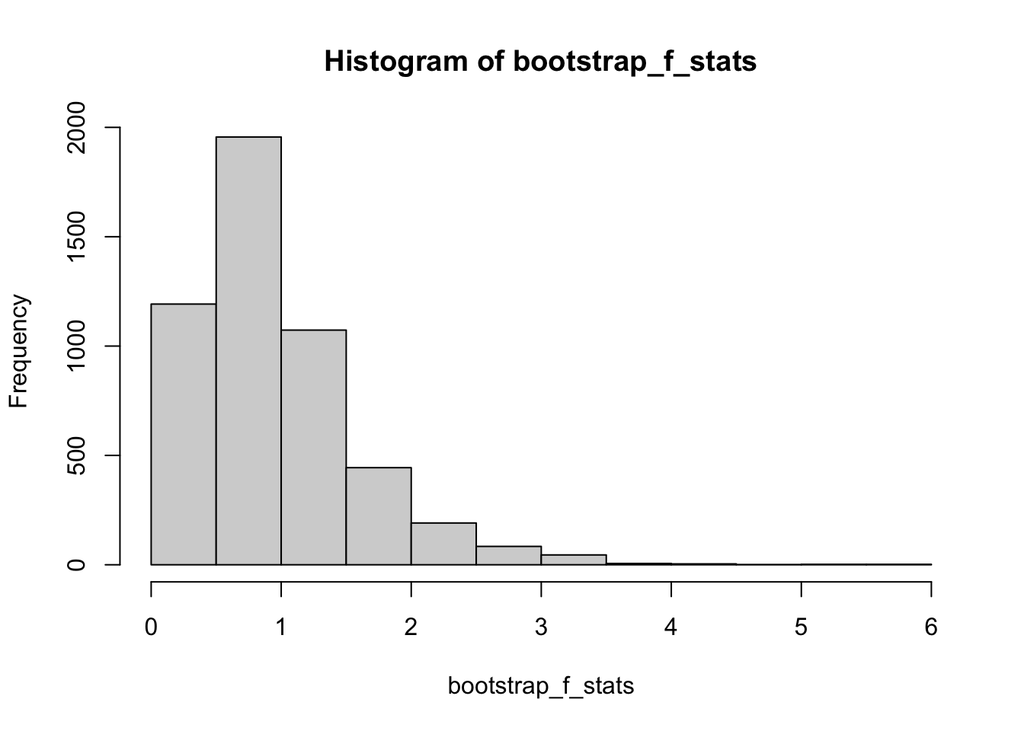

```r
hist(bootstrap_f_stats)
```

Most bootstrap F statistics were less than 1.88, but some were larger. $F = 1.88$ is in the right tail of the distribution, but not too far in the tail.

## Exercise 9

```r
bootstrap_p_value <- mean(bootstrap_f_stats > 1.88)
bootstrap_p_value
```

```
## [1] 0.0794
```

## Exercise 10

Our bootstrap p-value is pretty close to the parametric one!

Note: your bootstrap p-value will probably be slightly different to mine, just by chance. Remember each bootstrap sample is a random sample of the observed data.